# Hierarchical Clustering

Magdalena Löffler

`Dataset: Ice.csv`

For a study 102 children tasted 11 different types of ice cream (e.g. Magnum, Cornetto, Calippo). The children evaluated each type of ice cream on 14 properties. They classified statements like ‘tastes excellent’ or ‘looks good’ with ‘true’ or ‘false’. The data set (csv, rda) contains aggregated data, which for each combination of ice cream type and statement indicates the proportion of children who rated the statement as ‘true’.

Carry out a hierarchical cluster analysis (after scaling) using this data.

```
Which distance method do you think is most appropriate?
How many clusters do you choose?
Which properties are significantly different between the clusters?
```

Please upload a PDF or HTML file with your results for the tasks above along with your interpretations. Include the relevant code along with the output and graphics. (We recommend to prepare these from reproducible reports like R/Markdown or Jupyter, but it is also ok to simply use Word or any other text processor.)

```python
import pandas as pd
import numpy as np
from matplotlib import pyplot as plt
from scipy.cluster.hierarchy import dendrogram, linkage, cut_tree
from scipy.spatial.distance import pdist, squareform
from pca import pca
```

```python
pd.set_option("display.precision", 3)
path = "./data/Ice.csv"
df = pd.read_csv(path, header=0)
df.index.name = "ice_cream"
df.head()
```

| ice_cream | tastes_excellent | look_good | satisfies_hunger | satisfies_thirst | refreshing | for_everyday | for_special | for_adults | favorite | different | cool | never_eat | fun | expensive |
| --- | --- | --- | --- | --- | --- | --- | --- | --- | --- | --- | --- | --- | --- | --- |
| Nogger | 0.206 | 0.118 | 0.127 | 0.010 | 0.029 | 0.059 | 0.108 | 0.118 | 0.069 | 0.069 | 0.078 | 0.078 | 0.078 | 0.088 |
| Magnum | 0.412 | 0.343 | 0.294 | 0.020 | 0.069 | 0.225 | 0.265 | 0.392 | 0.245 | 0.186 | 0.245 | 0.029 | 0.088 | 0.549 |
| Cornetto | 0.480 | 0.294 | 0.294 | 0.049 | 0.108 | 0.196 | 0.294 | 0.402 | 0.265 | 0.088 | 0.098 | 0.029 | 0.118 | 0.353 |
| Viennetta | 0.118 | 0.137 | 0.078 | 0.000 | 0.029 | 0.049 | 0.275 | 0.284 | 0.039 | 0.088 | 0.020 | 0.088 | 0.049 | 0.196 |
| Max | 0.000 | 0.020 | 0.010 | 0.000 | 0.010 | 0.010 | 0.000 | 0.020 | 0.010 | 0.039 | 0.020 | 0.118 | 0.059 | 0.020 |

```python
# Scale data
ndf = (df-df.mean())/df.std()
ndf.head()
```

| ice_cream | tastes_excellent | look_good | satisfies_hunger | satisfies_thirst | refreshing | for_everyday | for_special | for_adults | favorite | different | cool | never_eat | fun | expensive |
| --- | --- | --- | --- | --- | --- | --- | --- | --- | --- | --- | --- | --- | --- | --- |
| Nogger | -0.251 | -0.502 | 0.271 | -0.686 | -0.797 | -0.943 | -0.048 | -0.080 | -0.679 | -0.490 | -0.333 | 0.347 | -0.704 | -0.295 |
| Magnum | 1.065 | 1.651 | 1.904 | -0.630 | -0.539 | 0.856 | 1.363 | 1.682 | 1.090 | 1.906 | 1.447 | -0.775 | -0.641 | 2.381 |
| Cornetto | 1.504 | 1.183 | 1.904 | -0.461 | -0.281 | 0.539 | 1.628 | 1.745 | 1.287 | -0.091 | -0.124 | -0.775 | -0.450 | 1.242 |
| Viennetta | -0.814 | -0.315 | -0.210 | -0.743 | -0.797 | -1.049 | 1.452 | 0.990 | -0.974 | -0.091 | -0.962 | 0.571 | -0.895 | 0.331 |
| Max | -1.566 | -1.439 | -0.882 | -0.743 | -0.926 | -1.472 | -1.019 | -0.710 | -1.269 | -1.089 | -0.962 | 1.244 | -0.831 | -0.694 |

```python
ndf.describe()
```

|  | tastes_excellent | look_good | satisfies_hunger | satisfies_thirst | refreshing | for_everyday | for_special | for_adults | favorite | different | cool | never_eat | fun | expensive |
| --- | --- | --- | --- | --- | --- | --- | --- | --- | --- | --- | --- | --- | --- | --- |
| count | 1.100e+01 | 1.100e+01 | 1.100e+01 | 1.100e+01 | 1.100e+01 | 1.100e+01 | 1.100e+01 | 1.100e+01 | 1.100e+01 | 1.100e+01 | 1.100e+01 | 1.100e+01 | 1.100e+01 | 1.100e+01 |
| mean | -2.624e-16 | -3.028e-17 | -4.037e-17 | -4.037e-17 | -1.009e-16 | -1.817e-16 | 2.321e-16 | -1.615e-16 | -1.877e-17 | 3.028e-16 | -5.993e-18 | -1.009e-16 | 5.046e-18 | 1.211e-16 |
| std | 1.000e+00 | 1.000e+00 | 1.000e+00 | 1.000e+00 | 1.000e+00 | 1.000e+00 | 1.000e+00 | 1.000e+00 | 1.000e+00 | 1.000e+00 | 1.000e+00 | 1.000e+00 | 1.000e+00 | 1.000e+00 |
| min | -1.566e+00 | -1.439e+00 | -8.820e-01 | -7.428e-01 | -9.263e-01 | -1.472e+00 | -1.019e+00 | -8.354e-01 | -1.269e+00 | -1.089e+00 | -1.066e+00 | -1.224e+00 | -8.950e-01 | -7.507e-01 |
| 25% | -5.638e-01 | -5.490e-01 | -5.938e-01 | -6.582e-01 | -7.973e-01 | -9.957e-01 | -6.657e-01 | -7.095e-01 | -8.266e-01 | -6.899e-01 | -8.569e-01 | -8.871e-01 | -7.679e-01 | -6.652e-01 |
| 50% | -6.265e-02 | -2.213e-01 | -3.057e-01 | -5.174e-01 | -4.104e-01 | 2.213e-01 | -3.128e-01 | -6.466e-01 | -2.860e-01 | -9.078e-02 | -1.238e-01 | 3.467e-01 | -4.504e-01 | -5.229e-01 |
| 75% | 7.204e-01 | 6.214e-01 | 7.860e-02 | 4.969e-01 | 7.182e-01 | 8.562e-01 | 6.577e-01 | 4.864e-01 | 1.090e+00 | 1.089e-01 | 6.617e-01 | 7.953e-01 | 7.246e-01 | 2.744e-01 |
| max | 1.504e+00 | 1.651e+00 | 1.904e+00 | 2.300e+00 | 2.040e+00 | 1.385e+00 | 1.628e+00 | 1.745e+00 | 1.287e+00 | 1.906e+00 | 1.552e+00 | 1.244e+00 | 1.646e+00 | 2.381e+00 |

## Hierarchical clustering

I tried out all different combinations of methods (average, single, complete) and different metrics (euclidean, manhattan, canberra). (I excluded some of them from the report since it would be quite long otherwise.)

### Which distance method is most appropriate?

The three combinations of linkage methods with the canberra distance were very different from those with euclidean and manhattan distance. What differenciates the canberra dendrograms from the others is mostly that Solero ice cream seems to be very different from the other ice creams. E.g. in the single linkage + canberra dendrogram, Solero is only merged at the very last step. For the other two distance measures this phenomenon that does not happen. However, I do not think that canberra method is optimal for this dataset, since the clusters seem not as homogeneous as with the other methods.

The biggest difference between euclidean and manhattan metric is the absoulte values of the distances: manhattan distances are much higher than euclidean distances. This is one reason why I think eudlidean distance might be more suitable here. However, euclidean and manhattan metrics yield somewhat similar dendrograms for each of the linkage methods. For both of them, single linkage is not optimal in this dataset because the heterogeneity of the cluster cannot be seen as well as in complete and average linkage.

To me, both of these structures make sense: Magnum/Cornetto and Twinni/Jolly/Calippo were the ice cream types that were liked the most in the survey. Therefore, complete linkage seems to highlight this association. However, Magnum and Cornetto were also very different from all the other ice cream types or in other words, Jolly/Twinni/Calippo shared some attributes with the third cluster (Level 0) and it is also reasonable to structure them like average linkage does. So I am unsure what other criteria there are to select the best linkage method in this case, to me, both complete and average linkage seem suitable and they both yield 3 very distinct clusters.

Since I have to decide on one, I would take average linkage + euclidean distance. Here, the 3 clusters are very distinct and they all have equal distances that make it clear where the cut should be made. Of course, the cluster that contains the most items could be split up further, but to me these ice creams have such big variation that it is hard to decide where the cut should be made. The plot with the PCs also shows the three clusters well.

[figure not shown]

```python
# hierachical clustering (average, euclidian)
hclust = linkage(ndf, method="average", metric="euclidean")
sorted_labels, indices = np.unique(ndf.index, return_inverse=True)
original_labels = sorted_labels[indices]
ice_cream_names = ndf.index
d = dendrogram(hclust, labels=ice_cream_names, leaf_rotation=90)
plt.show()
```

[figure not shown]

```python
# hierachical clustering (complete, euclidean)
hclust2 = linkage(ndf, method="complete", metric="euclidean")
sorted_labels, indices = np.unique(ndf.index, return_inverse=True)
original_labels = sorted_labels[indices]
d = dendrogram(hclust2, labels=ice_cream_names, leaf_rotation=90)
plt.show()
```

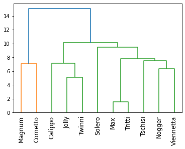

```python
# hierachical clustering (single, manhattan)
hclust3 = linkage(ndf, method="single", metric="cityblock")
sorted_labels, indices = np.unique(ndf.index, return_inverse=True)
original_labels = sorted_labels[indices]
d = dendrogram(hclust3, labels=ice_cream_names, leaf_rotation=90)
plt.show()
```

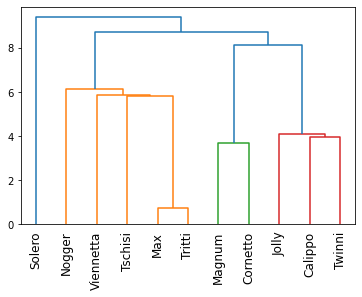

```python
# hierachical clustering (single, canberra)
hclust4 = linkage(ndf, method="single", metric="canberra")
sorted_labels, indices = np.unique(ndf.index, return_inverse=True)
original_labels = sorted_labels[indices]
d = dendrogram(hclust4, labels=ice_cream_names, leaf_rotation=90)
plt.show()
```

```python
cluster3 = pd.DataFrame({'ice_cream': ndf.index, 'Level': cut_tree(hclust, height=4)[:, 0]})
print(cluster3)
```

```
    ice_cream  Level
0      Nogger      0
1      Magnum      1
2    Cornetto      1
3   Viennetta      0
4         Max      0
5      Solero      0
6       Jolly      2
7     Calippo      2
8      Twinni      2
9      Tritti      0
10    Tschisi      0
```

```python
# add new column to dataframe with information about level
ndf_level = ndf.copy()
ndf_level.reset_index(inplace=True)
ndf_level["Level"] = cluster3["Level"]
ndf_level.head()
```

|  | ice_cream | tastes_excellent | look_good | satisfies_hunger | satisfies_thirst | refreshing | for_everyday | for_special | for_adults | favorite | different | cool | never_eat | fun | expensive | Level |
| --- | --- | --- | --- | --- | --- | --- | --- | --- | --- | --- | --- | --- | --- | --- | --- | --- |
| 0 | Nogger | -0.251 | -0.502 | 0.271 | -0.686 | -0.797 | -0.943 | -0.048 | -0.080 | -0.679 | -0.490 | -0.333 | 0.347 | -0.704 | -0.295 | 0 |
| 1 | Magnum | 1.065 | 1.651 | 1.904 | -0.630 | -0.539 | 0.856 | 1.363 | 1.682 | 1.090 | 1.906 | 1.447 | -0.775 | -0.641 | 2.381 | 1 |
| 2 | Cornetto | 1.504 | 1.183 | 1.904 | -0.461 | -0.281 | 0.539 | 1.628 | 1.745 | 1.287 | -0.091 | -0.124 | -0.775 | -0.450 | 1.242 | 1 |
| 3 | Viennetta | -0.814 | -0.315 | -0.210 | -0.743 | -0.797 | -1.049 | 1.452 | 0.990 | -0.974 | -0.091 | -0.962 | 0.571 | -0.895 | 0.331 | 0 |
| 4 | Max | -1.566 | -1.439 | -0.882 | -0.743 | -0.926 | -1.472 | -1.019 | -0.710 | -1.269 | -1.089 | -0.962 | 1.244 | -0.831 | -0.694 | 0 |

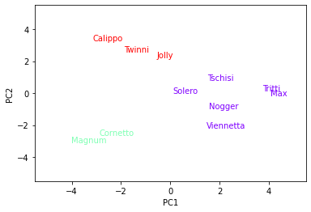

```python
ice_pca = pca(n_components=0.99, normalize=False)
pca_results = ice_pca.fit_transform(ndf, verbose=0)
pc = ice_pca.results['PC'].iloc[:, 0:2]

fig = plt.figure()
ax = plt.axis([-5.5, 5.5, -5.5, 5.5])
colors = plt.cm.get_cmap("rainbow", 3)

cluster3.set_index("ice_cream", inplace=True)

for index, row in pc.iterrows():
    color = colors(cluster3.loc[index][0])
    plt.text(row["PC1"], row["PC2"], index, {"color": color})

plt.xlabel("PC1")
plt.ylabel("PC2")
plt.show()
```

## Which properties are significantly different between the clusters?

The biplot shown below helps to identify the attributes that are different between the clusters: Calippo/Twinni/Jolly (Level 2) are defined strongly by refreshing, satisfies_thirst and fun, while Magnum/Cornetto (Level 1) is defined by satisfies_hunger, for_special, for_adults, and expensive. Both clusters are also defined by positive attributes like look_good, tastes_excellent, favorite. These attributes set them apart from the remaining group (Level 0) which is mostly positioned on the right side. The positive values for PC1 here show the attribute never_eat.

The boxplot diagrams below also show that *satisfies hunger/thirst, refreshing, for adults, never eat, fun* and *expensive* differ a lot between the clusters; for these attributes, the boxplot diagrams show rather small ranges within one cluster and very different values between the clusters. In contrast, this is not the case for attributes like *cool* or *different*. Here, the range is much higher and the mean values are also more similar.

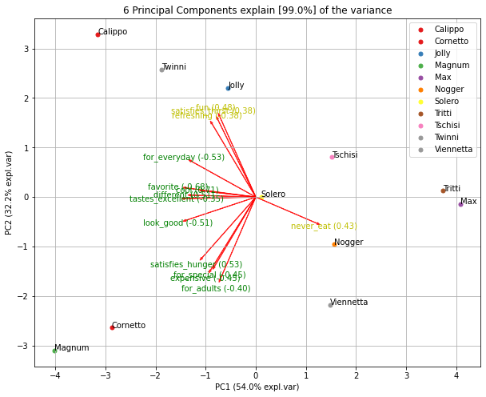

```python
fix, ax = ice_pca.biplot()

plt.show()
```

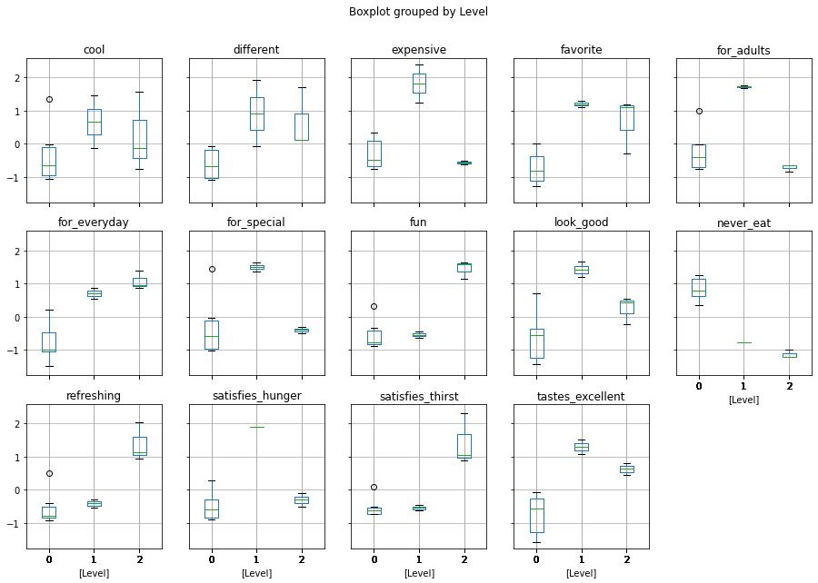

```python
# my not so elegant solution to show the plots
# cols = ndf.columns    #to show all boxplots
#cols = ["satisfies_hunger", "satisfies_thirst", "refreshing", "for_adults", "never_eat", "fun", "expensive"]
#for c in cols:
#    boxplot = ndf_level.boxplot(column=c, by='Level')
#    plt.show()

# elegant version ;)
ndf_level.boxplot(by="Level", figsize=(15,10), layout=(3,5));
```

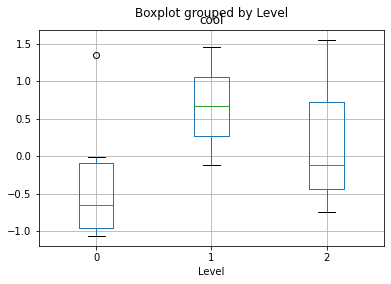

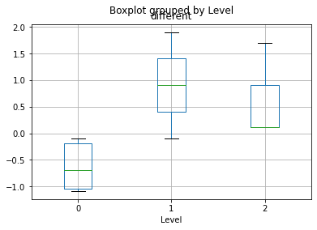

```python
# attributes that are not important to distinguish the ice creams:
cols = ["cool", "different"]
for c in cols:
    boxplot = ndf_level.boxplot(column=c, by='Level')
    plt.show()
```